# Barbell Lift Detection

Michael Kamfonas

November 17, 2015

## Introduction

This is an assigned project for the Coursera Machine Learning course. Data have been downloaded to local directory from:

- https://d396qusza40orc.cloudfront.net/predmachlearn/pml-training.csv
- https://d396qusza40orc.cloudfront.net/predmachlearn/pml-testing.csv

Documentation is here: http://groupware.les.inf.puc-rio.br/har

### Acknowledgement

Velloso, E.; Bulling, A.; Gellersen, H.; Ugulino, W.; Fuks, H. Qualitative Activity Recognition of Weight Lifting Exercises. Proceedings of 4th International Conference in Cooperation with SIGCHI (Augmented Human ’13) . Stuttgart, Germany: ACM SIGCHI, 2013.

Read more: http://groupware.les.inf.puc-rio.br/har#ixzz3rmC336RS

### Data Load and Preparation

```r
require(caret);
testRaw<-read.csv("pml-testing.csv")
trainRaw<-read.csv("pml-training.csv")
#str(trainRaw,list.len = 160)
dim(trainRaw);dim(testRaw)
```

```
## [1] 19622   160
```

```
## [1]  20 160
```

```r
M<-nearZeroVar(trainRaw,saveMetrics = TRUE) # find near-zero and zero values
M<-cbind(M,trainClass=sapply(trainRaw,class),testClass=sapply(testRaw,class))
M<-cbind(M,naTrainCount=apply(trainRaw,2,FUN=function(C){sum(is.na(C))}))
M<-cbind(M,naTestCount=apply(testRaw,2,FUN=function(C){sum(is.na(C))}))
M<-cbind(M,emptyCount=apply(trainRaw,2,FUN=function(C){sum(C==""||C==" ")}))
M<-cbind(M,invalidCount=apply(trainRaw,2,FUN=function(C){sum(C=="#DIV/0!")}))
M$class.mismatch <- as.character(M$trainClass)!=as.character(M$testClass)
View(M)
```

## Covariate Selection

### Remove identifiers, NAs and NZVs

```r
require(dplyr);require(tidyr)
M$filterNames<- M$naTestCount==0
M$filterNames[1:7] <- FALSE
colList <- row.names(M[M$filterNames,])
colList <- c(colList,"problem_id")                  # last var is different in training and testing
training <-trainRaw[,names(trainRaw) %in% colList]  # variables to use from training set
testing  <-testRaw[,names(testRaw) %in% colList]    # variables to use from test set
nearZeroVar(training)                               # verify no near-zero covariates
```

```
## integer(0)
```

### Check for correlated predictors.

```r
C <- abs(cor(training[,! names(training) %in% c("classe")]))
dim(C)
```

```
## [1] 52 52
```

```r
diag(C) <- 0
which(C > 0.9,arr.ind=T)
```

```
##                  row col
## total_accel_belt   4   1
## accel_belt_y       9   1
## accel_belt_z      10   1
## accel_belt_x       8   2
## roll_belt          1   4
## accel_belt_y       9   4
## accel_belt_z      10   4
## pitch_belt         2   8
## roll_belt          1   9
## total_accel_belt   4   9
## accel_belt_z      10   9
## roll_belt          1  10
## total_accel_belt   4  10
## accel_belt_y       9  10
## gyros_arm_y       19  18
## gyros_arm_x       18  19
## gyros_dumbbell_z  33  31
## gyros_forearm_z   46  31
## gyros_dumbbell_x  31  33
## gyros_forearm_z   46  33
## gyros_dumbbell_x  31  46
## gyros_dumbbell_z  33  46
```

Apparently there are a number of highly correlated variables. Principal component analysis is a better way to address this.

### Preliminary PCA

Check PCA for all variables and plot first two with color that correpsonds to classe:

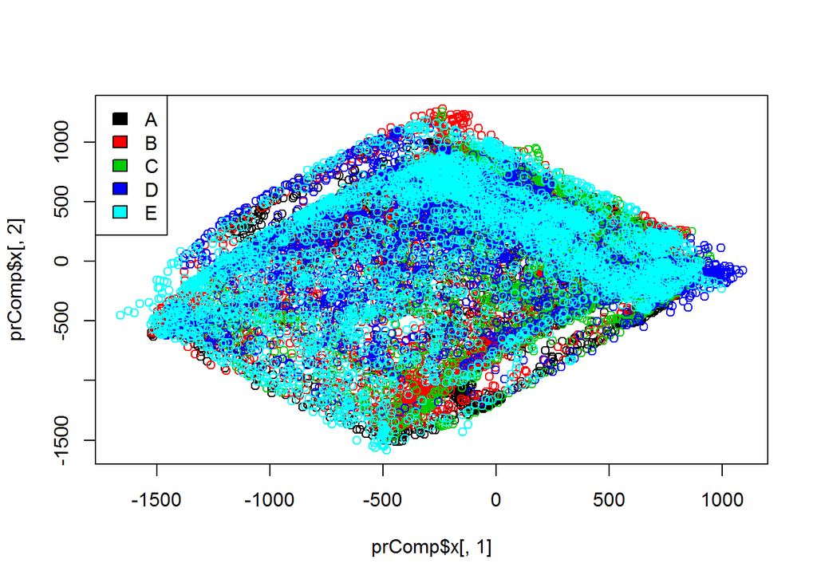

```r
trainCoVars<-training[,! names(training) %in% c("classe")]
prComp <- prcomp(trainCoVars)
plot(prComp$x[,1],prComp$x[,2],col=training$classe)
legend("topleft",legend=levels(training$classe),fill =unique(as.integer(training$classe)))
```

We further develop four models, two of which are using PCA to limit predictors.

## Analysis

### Simple Clustering

```r
modFit <- train(classe ~ . , method="rpart",data=training)
modFit
```

```
## CART
##
## 19622 samples
##    52 predictor
##     5 classes: 'A', 'B', 'C', 'D', 'E'
##
## No pre-processing
## Resampling: Bootstrapped (25 reps)
## Summary of sample sizes: 19622, 19622, 19622, 19622, 19622, 19622, ...
## Resampling results across tuning parameters:
##
##   cp          Accuracy   Kappa       Accuracy SD  Kappa SD
##   0.03567868  0.5147726  0.37096174  0.04012665   0.06792588
##   0.05998671  0.4219490  0.21889482  0.06595474   0.10871870
##   0.11515454  0.3296644  0.06886011  0.04074167   0.06231835
##
## Accuracy was used to select the optimal model using  the largest value.
## The final value used for the model was cp = 0.03567868.
```

This is an unsatisfactory solution with low accuracy.

```r
library(rattle)
```

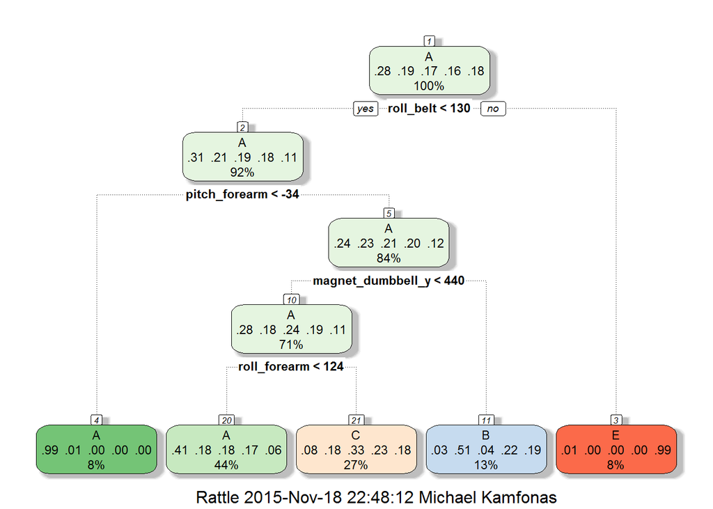

```r
fancyRpartPlot(modFit$finalModel)
```

### Clustering with PCA

```r
modFit <- train(classe ~ .,method="rpart",preProcess="pca", data=training)
modFit
```

```
## CART
##
## 19622 samples
##    52 predictor
##     5 classes: 'A', 'B', 'C', 'D', 'E'
##
## Pre-processing: principal component signal extraction (52), centered
##  (52), scaled (52)
## Resampling: Bootstrapped (25 reps)
## Summary of sample sizes: 19622, 19622, 19622, 19622, 19622, 19622, ...
## Resampling results across tuning parameters:
##
##   cp          Accuracy   Kappa      Accuracy SD  Kappa SD
##   0.03567868  0.3748473  0.1596939  0.031208787  0.06188988
##   0.05998671  0.3559871  0.1230117  0.022154370  0.04162943
##   0.11515454  0.2842146  0.0000000  0.005033864  0.00000000
##
## Accuracy was used to select the optimal model using  the largest value.
## The final value used for the model was cp = 0.03567868.
```

[figure not shown]

```r
library(rattle)
fancyRpartPlot(modFit$finalModel)
```

### Analysis with Random Forest

We will first limit PCA to use the top 10 variables. Attempts to run with all variables takes way too long. We generate the top 10 variables into a prepared.training and prepared.testing data frames using the caret preProcess function. We also choose to use proximity = FALSE when training to improve performance.

```r
require(caret);
training.covars <- training[,! names(training) %in% c("classe")]
testing.covars <- testing[,! names(testing) %in% c("problem_id")]
training.outcome <- training$classe
preProc <- preProcess(training.covars,method="pca",pcaComp=10)
prepared.training <- predict(preProc,training.covars)
prepared.testing <- predict(preProc,testing.covars)
```

A plot that follows shows the top two of the PCA-derived covariates with points colored according to the five classes. Two variables are not enough to see a pattern, but the segregation of types starts to become evident.

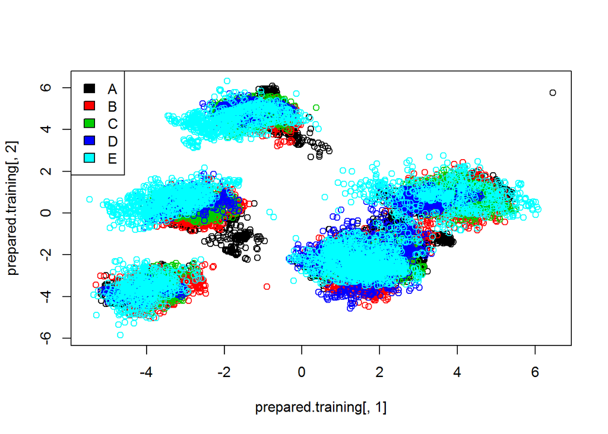

```r
plot(prepared.training[,1],prepared.training[,2],col=training$classe)
legend("topleft",legend=levels(training$classe),fill =unique(as.integer(training$classe)))
```

```r
modFit <- train(training.outcome ~ . ,
                method="rf",
                proximity = FALSE ,
                data=prepared.training)
modFit
```

```
## Random Forest
##
## 19622 samples
##     9 predictor
##     5 classes: 'A', 'B', 'C', 'D', 'E'
##
## No pre-processing
## Resampling: Bootstrapped (25 reps)
## Summary of sample sizes: 19622, 19622, 19622, 19622, 19622, 19622, ...
## Resampling results across tuning parameters:
##
##   mtry  Accuracy   Kappa      Accuracy SD  Kappa SD
##    2    0.9534633  0.9411108  0.003038540  0.003836290
##    6    0.9472579  0.9332679  0.003669397  0.004636266
##   10    0.9382096  0.9218238  0.004436566  0.005613195
##
## Accuracy was used to select the optimal model using  the largest value.
## The final value used for the model was mtry = 2.
```

The model has good accuracy and its confusion matrix looks satisfactory, This is our best model so far. Given the 95% accuracy, we still expect to miss one or two of the test predictions.

```r
modFit$finalModel
```

```
##
## Call:
##  randomForest(x = x, y = y, mtry = param$mtry, proximity = FALSE)
##                Type of random forest: classification
##                      Number of trees: 500
## No. of variables tried at each split: 2
##
##         OOB estimate of  error rate: 3.01%
## Confusion matrix:
##      A    B    C    D    E class.error
## A 5486   26   45   18    5  0.01684588
## B   71 3644   59   18    5  0.04029497
## C   28   40 3308   41    5  0.03331385
## D   28    9  116 3055    8  0.05006219
## E    6   20   26   17 3538  0.01912947
```

We use the prepared.testing data set for prediction followed by processing the data for submitting answers.

```r
  pred <- predict(modFit,newdata = prepared.testing)
  answ <- as.character(pred)
  answ
```

```
##  [1] "B" "A" "A" "A" "A" "E" "D" "B" "A" "A" "A" "C" "B" "A" "E" "E" "A"
## [18] "B" "B" "B"
```

```r
  pml_write_files = function(x){
  n = length(x)
  for(i in 1:n){
    filename = paste0("problem_id_",i,".txt")
    write.table(x[i],file=filename,quote=FALSE,row.names=FALSE,col.names=FALSE)
  }
}
projDir<- getwd()
setwd("answers")
pml_write_files(answ)
setwd(projDir)
getwd()
```

```
## [1] "D:/Coursera/work/R8-PracticalMachineLearning/Project"
```

As suspected, two of our submissions were incorrect. Next we will try all non-NA variables so we don’t need PCA.

```r
modFit2 <- train(training.outcome ~ . ,
                method="rf",
                proximity = FALSE ,
                data=training.covars)
modFit2
```

```
## Random Forest
##
## 19622 samples
##    51 predictor
##     5 classes: 'A', 'B', 'C', 'D', 'E'
##
## No pre-processing
## Resampling: Bootstrapped (25 reps)
## Summary of sample sizes: 19622, 19622, 19622, 19622, 19622, 19622, ...
## Resampling results across tuning parameters:
##
##   mtry  Accuracy   Kappa      Accuracy SD  Kappa SD
##    2    0.9926563  0.9907098  0.001204219  0.001522565
##   27    0.9924487  0.9904467  0.001264157  0.001602123
##   52    0.9849237  0.9809256  0.002715151  0.003441652
##
## Accuracy was used to select the optimal model using  the largest value.
## The final value used for the model was mtry = 2.
```

The model has good accuracy, OOB error of 0.4% and it should provide the best prediction of all models tried. Its confusion matrix confirms this.

```r
modFit2$finalModel
```

```
##
## Call:
##  randomForest(x = x, y = y, mtry = param$mtry, proximity = FALSE)
##                Type of random forest: classification
##                      Number of trees: 500
## No. of variables tried at each split: 2
##
##         OOB estimate of  error rate: 0.43%
## Confusion matrix:
##      A    B    C    D    E  class.error
## A 5578    2    0    0    0 0.0003584229
## B   12 3782    3    0    0 0.0039504872
## C    0   18 3401    3    0 0.0061367621
## D    0    0   38 3177    1 0.0121268657
## E    0    0    1    6 3600 0.0019406709
```

Compare results between answ2 (last attempt) and previous attempt ans2:

```r
  pred2 <- predict(modFit2,newdata = testing.covars)
  answ2 <- as.character(pred2)
  answ2
```

```
##  [1] "B" "A" "B" "A" "A" "E" "D" "B" "A" "A" "B" "C" "B" "A" "E" "E" "A"
## [18] "B" "B" "B"
```

```r
  answ
```

```
##  [1] "B" "A" "A" "A" "A" "E" "D" "B" "A" "A" "A" "C" "B" "A" "E" "E" "A"
## [18] "B" "B" "B"
```

```r
projDir<- getwd()
setwd("answer2")
pml_write_files(answ2)
setwd(projDir)
getwd()
```

```
## [1] "D:/Coursera/work/R8-PracticalMachineLearning/Project"
```